# Relatório - Projeto - Servidor Web para publicação de uma foto e dados de sensores

# 1 - Partes do Projeto e componentes utilizados:

## 1.1 - As três partes do projeto:

- 1 - Circuito usando placa de desenvolvimento ‘NodeMCU V1.0’ - SoC ESP12-E (com microcontrolador ESP8266).
  - Lê os dados de temperatura e pressão do módulo BMP280 e o valor analógico do sensor de iluminação (fotoresistor).
  - Os dados dos sensores são enviados para o servidor MQTT.
  - O NodeMCU é alimentado por meio de uma bateria 18650.
  - A bateria é carregada por meio de painéis solares.
- 2 - Módulo ESP32-CAM:
  - Tira uma foto a cada 5 minutos. Ele apenas armazena a última foto tirada.
  - Esse módulo também hospeda o servidor web com a página que mostra os dados dos sensores e a ultima foto tirada com a câmera.
  - Na memória flash do ESP32-CAM somente é armazenada a foto mostrada na página.
  - O código HTML da página web é gerado nas funções do *sketch* enviado para o ESP32-Cam.
- 3 - Computador executando o **Moquitto MQTT** e o programa Ngrok.
  - No caso aqui, os programas estão instalados em um Raspberry Pi.
  - Entretanto, qualquer computador com Windows pode fazer exatamente a mesma coisa. Somente é necessário instalar os programas mencionados.
  - **Mosquitto MQTT**: É o programa que recebe os dados das leituras dos sensores, realizadas no NodeMCU ESP8266, e envia essas informações ao ESP32-CAM para incluir as leituras realizadas na página web gerada.
  - **Ngrok**: é o serviço de internet que faz com que o servidor web do ESP32-CAM fique disponível na internet.
    - Necessário criar uma conta no site.
    - O site disponibiliza uma versão gratuita e, também, recursos pagos.
    - Os recursos usados aqui foram os gratuitos.

## 1.2 - Componentes utilizados no projeto:

[figure not shown]

Foto_01

[figure not shown]

Foto_02

- 2 - **Módulo ESP32-CAM com o servidor Web**:
  - 1x Módulo ESP32-CAM
  - 1x Módulo programador **FT232R FTDI** (o ESP32-CAM não é programado de forma direta como nas placas NodeMCU).
  - 1x Uma fonte de 5V

# 2 - Diagramas e fotos dos circuitos:

## 2.1 - Parte 1 - ESP8266 e sensores

### 2.1.1 - Alimentação (painéis solares)

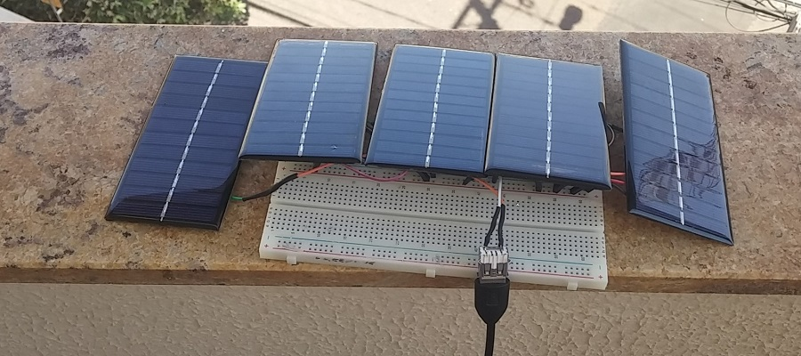

[figure not shown]

### 2.1.2 - NodeMCU e Sensores

[figure not shown]

[figure not shown]

### 2.1.3 - Selecionar o NodeMCU no Arduino IDE

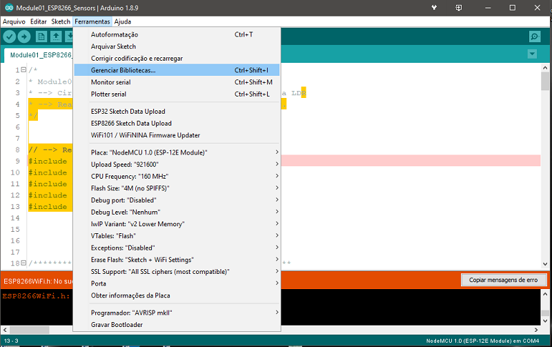

Foto_05

### 2.1.4 - Servidor MQTT:

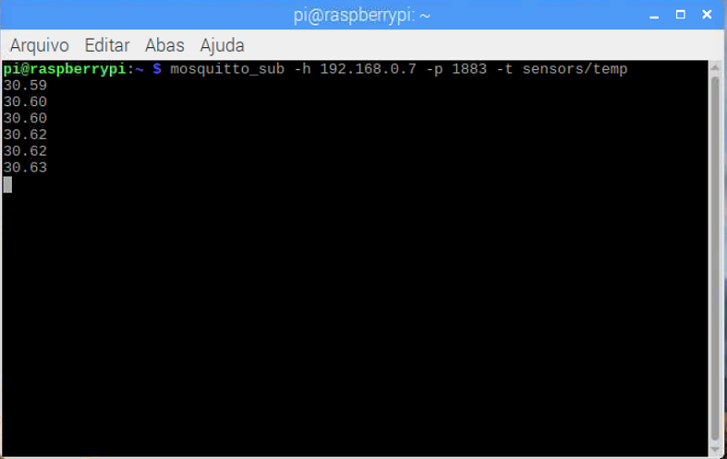

Subscrever Tópico no Mosquitto

- Os valores retornados pelas leituras dos sensores são publicados no servidor MQTT executado no Raspberry Pi.
- O programa usado aqui é o **Moquito MQTT Broker**.
- A imagem acima mostra o resultado de uma subscrição ao tópico **`sensors/temp`**.

[figure not shown]

MyMQTT (Android) Screenshot

- Alternativamente, as leituras de um tópico MQTT também podem ser apresentadas no aplicativo **MyMQTT** (Android).
- A imagem acima mostra o MyMQTT recebendo os dados do servidor MQTT executado no Raspberry Pi.
- Os tópicos subscritos foram:
  - **`sensors/temp`**.
  - **`sensors/pressure`**.
  - **`sensors/adc_ldr`**.

## 2.2 - Parte 2 - ESP32-CAM

### 2.2.1 - Programação do ESP32-CAM

[figure not shown]

[figure not shown]

- O ESP32-CAM precisa de ser programado através de um programador FTDI.
  - Nas imagens acima, ele está sendo programado usando um módulo **FT232R FTDI**.
  - No momento de programar o ESP32-CAM, colocá-lo em *boot mode*, **conectando os pinos `IO0` e `GND`**.

### 2.2.2 - Selecionando o ESP32-CAM no Arduino IDE:

[figure not shown]

Img_09

### 2.2.3 - Execução

[figure not shown]

[figure not shown]

- Para executar o *sketch* enviado para o ESP32-CAM, basta remover o fio conectando os pinos `IO0` e `GND`.

### 2.2.4 - O Servidor Web no ESP32-CAM:

[figure not shown]

[figure not shown]

- Como mostra o output no Arduino IDE, o sevidor web está disponível na rede Wi-Fi no endereço **`192.168.0.9:8888`**.

### 2.2.5 - O serviço de redirecionamento Ngrok:

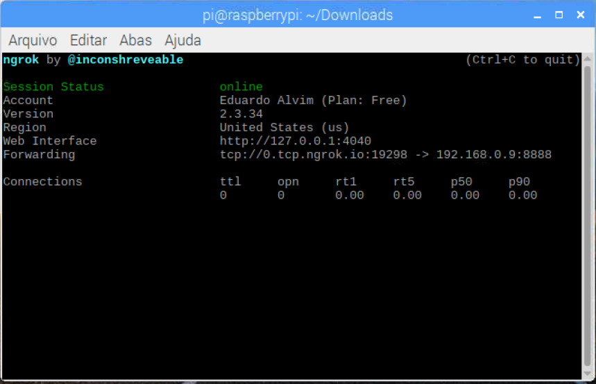

[figure not shown]

- Antes de realizar o procedimento, se cadastrar no site do Ngrok, baixar, instalar e configurar o programa do Ngrok.
- Procedimento:
  - 1 - Ir para o diretório onde o Ngrok está instalado (no Windows, caso tenha adicionado o caminho para o executável do Ngrok à variável de ambiente `PATH`, esse procedimento não é necessário).
  - 2 - Executar Ngrok especificando o endereo do servidor web na rede Wi-Fi:
    - **Raspberry Pi**: `./ngrok tcp 192.168.0.9:8888`
    - **Windows Power Shell**: `ngrok tcp 192.168.0.9:8888`
    - Lembrando que o endereço especificado nos comandos acima somente valem no caso do endereço de IP do ESP32-CAM na rede Wi-Fi ser `192.168.0.9`.
  - O output mostrado na primeira imagem mostra que o endereço de internet para acessar o servidor web em qualquer lugar é: **`http://0.tcp.ngrok.io:19298/`** .